# Daily Sales Analysis for a French Bakery

In this notebook, we'll dive into the daily sales of a local French bakery. From the top-selling items to peak sales times, let's uncover some delicious insights!

1. Loading the Data and Necessary Libraries
2. Data Exploration
3. Memory Optimization Techniques
4. Data Cleaning
5. Sales Trends Analysis
6. Top Selling Items
7. Peak Sales Times
8. Average Revenue per Transaction
9. Conclusion

## Loading the Data and Necessary Libraries

```python
import pandas as pd
import matplotlib.pyplot as plt

# Load the data
# (csv file from https://www.kaggle.com/datasets/matthieugimbert/french-bakery-daily-sales)
df = pd.read_csv("bakery sales.csv")
```

## Initial Data Exploration

Let's take a quick look at the first few rows of the data and its basic information.

```python
# drop Unnamed: 0 column
df.drop('Unnamed: 0', axis=1, inplace=True)
# Display the first few rows
df.head()
```

|  | date | time | ticket_number | article | Quantity | unit_price |
| --- | --- | --- | --- | --- | --- | --- |
| 0 | 2021-01-02 | 08:38 | 150040.0 | BAGUETTE | 1.0 | 0,90 € |
| 1 | 2021-01-02 | 08:38 | 150040.0 | PAIN AU CHOCOLAT | 3.0 | 1,20 € |
| 2 | 2021-01-02 | 09:14 | 150041.0 | PAIN AU CHOCOLAT | 2.0 | 1,20 € |
| 3 | 2021-01-02 | 09:14 | 150041.0 | PAIN | 1.0 | 1,15 € |
| 4 | 2021-01-02 | 09:25 | 150042.0 | TRADITIONAL BAGUETTE | 5.0 | 1,20 € |

```python
# General information about the data
df.info()
```

```
<class 'pandas.core.frame.DataFrame'>
RangeIndex: 234005 entries, 0 to 234004
Data columns (total 6 columns):
 #   Column         Non-Null Count   Dtype
---  ------         --------------   -----
 0   date           234005 non-null  object
 1   time           234005 non-null  object
 2   ticket_number  234005 non-null  float64
 3   article        234005 non-null  object
 4   Quantity       234005 non-null  float64
 5   unit_price     234005 non-null  object
dtypes: float64(2), object(4)
memory usage: 10.7+ MB
```

## Memory Optimization Techniques

First, let's check the current memory usage:

```python
# Initial Memory Usage
initial_memory = df.memory_usage(deep=True).sum() / 1024 ** 2 # convert bytes to MB
# deep=True: Introspect the data deeply, interrogate object dtypes for
# system-level memory consumption
# That's why the memory usage is higher than the df.info() result
print(f"Initial memory usage: {initial_memory:.2f} MB")
```

```
Initial memory usage: 68.94 MB
```

### Convert Data Types

One of the easiest ways to reduce memory usage is by converting data types. For example, `float64` can often be safely downcast to `float32`, and `int64` can often become `int32` or even smaller data types.

```python
# create a copy of the dataframe for testing memory usage
df_copy = df.copy()


# 'unit_price' is in string format with the Euro symbol, and comma as
#  a decimal separator
# remove the Euro symbol
df_copy['unit_price'] = df_copy['unit_price'].str.replace(' €', '')
# replace comma with dot
df_copy['unit_price'] = df_copy['unit_price'].str.replace(',', '.')

# Downcasting unit_price column
df_copy['unit_price'] = pd.to_numeric(df_copy['unit_price'], downcast='float')
# Downcasting Quantity column
df_copy['Quantity'] = pd.to_numeric(df_copy['Quantity'], downcast='integer')


# Verifying the new memory usage
optimized_memory = df_copy.memory_usage(deep=True).sum() / 1024 ** 2  # in MB
print(f"Optimized memory usage: {optimized_memory:.2f} MB")
```

```
Optimized memory usage: 47.52 MB
```

### Use Category Data Type for Text Columns with Low Cardinality

Columns that have a low number of unique values (low cardinality) can be converted to the `category` data type.

```python
df_copy['article'] = df_copy['article'].astype('category')

# Verifying the new memory usage
optimized_memory2 = df_copy.memory_usage(deep=True).sum() / 1024 ** 2  # in MB
print(f"Further optimized memory usage: {optimized_memory2:.2f} MB")
```

```
Further optimized memory usage: 32.37 MB
```

### Modularisation of memory optimization

We can create a function that exemplifies modularization by streamlining the task of memory optimization into a single, reusable component. It can be placed in an external Python file for easy import into various projects, enhancing both maintainability and reusability.

```python
def optimize_memory(df, obj_cols_to_optimize = [], in_place=False):
    """
    Optimizes the memory usage of a DataFrame by downcasting numerical and
    specified object columns.

    Parameters:
        df (pandas.DataFrame): DataFrame to optimize
        obj_cols_to_optimize (list): List of object column names to convert to 'category'
        in_place (bool): Whether to modify the original DataFrame in place

    Returns:
        pandas.DataFrame: Optimized DataFrame if in_place is False, otherwise None
    """

    if not in_place:
        df = df.copy()

    # Downcast integer columns
    int_cols = df.select_dtypes(include=['int']).columns
    df[int_cols] = df[int_cols].apply(pd.to_numeric, downcast='integer')

    # Downcast float columns
    float_cols = df.select_dtypes(include=['float']).columns
    df[float_cols] = df[float_cols].apply(pd.to_numeric, downcast='float')

    # Downcast specified object columns
    for col in obj_cols_to_optimize:

        # Check if column exists and is actually of object dtype
        if col in df.columns and df[col].dtype == 'object':
            # Convert to category
            df[col] = df[col].astype('category')

    if in_place:
        return None
    else:
        return df
```

```python
df_copy = df.copy()
# 'unit_price' is in string format with the Euro symbol, and comma as a decimal separator
df_copy['unit_price'] = df_copy['unit_price'].str.replace(' €', '').str.replace(',', '.').astype('float').astype('float32')

df_memory_optimized = optimize_memory(df_copy, obj_cols_to_optimize=['article'], in_place=False)
print(f"Memory usage after full optimization: {df_memory_optimized.memory_usage(deep=True).sum() / 1024 ** 2:.2f} MB")
```

```
Memory usage after full optimization: 31.93 MB
```

```python
df_memory_optimized.info()
```

```
<class 'pandas.core.frame.DataFrame'>
RangeIndex: 234005 entries, 0 to 234004
Data columns (total 6 columns):
 #   Column         Non-Null Count   Dtype
---  ------         --------------   -----
 0   date           234005 non-null  object
 1   time           234005 non-null  object
 2   ticket_number  234005 non-null  float32
 3   article        234005 non-null  category
 4   Quantity       234005 non-null  float32
 5   unit_price     234005 non-null  float32
dtypes: category(1), float32(3), object(2)
memory usage: 6.7+ MB
```

### Further Techniques for Optimizing Memory Usage

Here, we have demonstrated some common techniques to optimize memory usage, focusing mainly on data type conversion and column pruning. While these steps might seem trivial for our small bakery dataset, they can make a significant difference in larger projects.

#### Additional Techniques Worth Considering:

1. **Load Only Necessary Rows and Columns**: When initially exploring data, consider loading only a subset of rows and only the columns you need. This can be easily done using the `nrows` and `usecols` parameters in `pandas.read_csv()` or similar functions in other data-loading libraries.

   ```
   # Example: Load only first 1000 rows and selected columns
    df_sample = pd.read_csv("bakery sales.csv", nrows=1000, usecols=['date', 'time', 'article'])
   ```

2. **Data Sampling**: For preliminary analyses, sometimes working with a representative sample of your data can be as good as using the entire dataset. This also significantly reduces memory usage.

   ```
   # Example: Random sampling of 10% of the dataset
    df_sample = df.sample(frac=0.1)
   ```

By employing these and previously discussed methods, you can ensure that your Jupyter Notebooks remain efficient, allowing you to tackle datasets that might otherwise require more substantial computing resources.

## Data Cleaning

Before we move on to the analysis, let's clean the data by converting types and handling missing values.

```python
# 'unit_price' is in string format with the Euro symbol, and comma as a decimal separator
df['unit_price'] = df['unit_price'].str.replace(',', '.').str.extract('(\d+\.\d+)').astype(float)

# Drop any rows with missing values
df.dropna(inplace=True)
```

## Sales Trend Analysis

We will examine the trends in sales over time

```python
# Convert 'date' column to datetime
df['date'] = pd.to_datetime(df['date'])
```

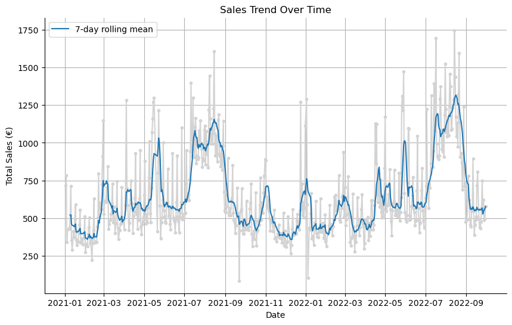

```python
# Aggregate sales data by date
df_sales_trend = df.groupby('date')['unit_price'].sum().reset_index()

# Plotting
plt.figure(figsize=(10, 6))
plt.plot(df_sales_trend['date'], df_sales_trend['unit_price'], marker='.', color='lightgrey')
# rolling mean
plt.plot(df_sales_trend['date'], df_sales_trend['unit_price'].rolling(7).mean(), color='tab:blue', label='7-day rolling mean')
plt.title('Sales Trend Over Time')
plt.xlabel('Date')
plt.ylabel('Total Sales (€)')
plt.legend()
plt.grid(True)
# despine
plt.gca().spines['top'].set_visible(False)
plt.gca().spines['right'].set_visible(False)
plt.show()
```

The trend line clearly indicates **peaks during the summer months**, specifically **July and August**. This could be attributed to a variety of factors, such as **increased tourism** or **seasonal demand for certain bakery items**.

Additionally, there are **noticeable spikes in sales** on **specific days throughout the year**, such as during the **Christmas season**. These peaks likely correspond to **holidays or special occasions** when people are more inclined to indulge in baked goods or purchase them for gatherings.

## Top-Selling Items

Next, let's identify which items are our top sellers. This can help us focus on what's driving most of our revenue.

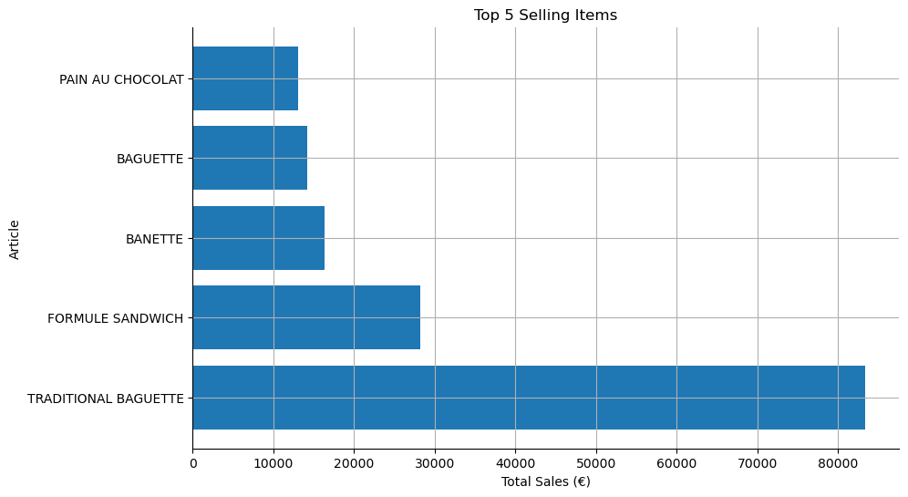

```python
# Aggregate sales data by article
df_top_selling = df.groupby('article')['unit_price'].sum().reset_index()

# Sort and take top 5
df_top_selling = df_top_selling.sort_values(by='unit_price', ascending=False).head(5)

# Plotting
plt.figure(figsize=(10, 6))
plt.barh(df_top_selling['article'], df_top_selling['unit_price'], color='tab:blue')
plt.xlabel('Total Sales (€)')
plt.ylabel('Article')
plt.title('Top 5 Selling Items')
plt.grid(True)
# despine
plt.gca().spines['top'].set_visible(False)
plt.gca().spines['right'].set_visible(False)
plt.show()
```

The bar chart below highlights the **top 5 selling items** in terms of revenue generated:

These items represent the **core revenue drivers** for the bakery. The **Traditional Baguette** leads the list by a substantial margin, accounting for a significantly larger share of revenue compared to other items. Understanding the sales distribution across these top-selling items can guide **product focus** and **promotional strategies**.

## Peak Sales Times

To optimize staffing and inventory, it's essential to understand the peak sales times. Let's identify when we are busiest.

```python
# First, ensure the time is in string format
df['time'] = df['time'].astype(str)

# Convert it to datetime.time
df['time'] = pd.to_datetime(df['time'], format='%H:%M').dt.time
```

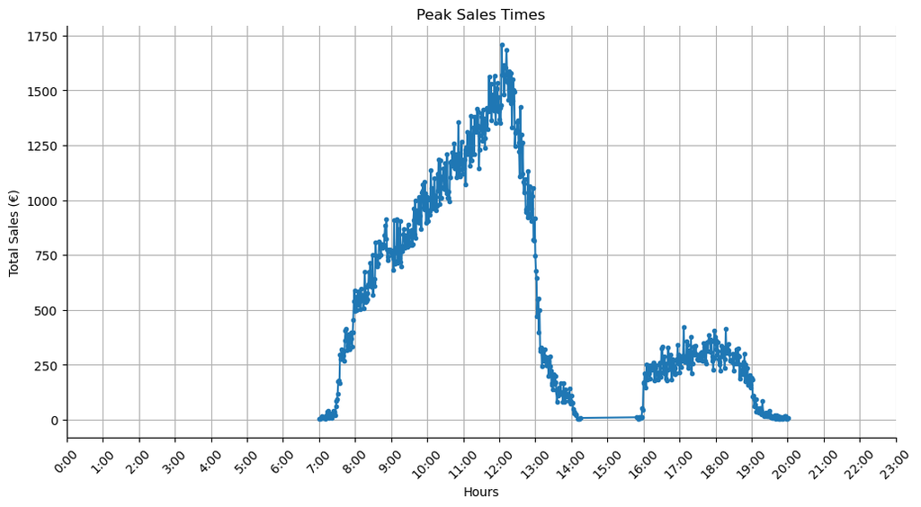

```python
# Convert time to minutes past midnight for easier aggregation
df['minutes_past_midnight'] = df['time'].apply(lambda t: t.hour * 60 + t.minute)

# Aggregate sales data by time
df_peak_times = df.groupby('minutes_past_midnight')['unit_price'].sum().reset_index()

# Plotting
plt.figure(figsize=(12, 6))
plt.plot(df_peak_times['minutes_past_midnight'], df_peak_times['unit_price'], marker='.', color='tab:blue')
plt.title('Peak Sales Times')
plt.xlabel('Hours')
plt.ylabel('Total Sales (€)')
plt.xticks(ticks=range(0, 24*60, 60), labels=[f"{i}:00" for i in range(24)], rotation=45)
plt.grid(True)
# despine
plt.gca().spines['top'].set_visible(False)
plt.gca().spines['right'].set_visible(False)
plt.show()
```

The plot below illustrates the **peak sales times** during a typical day at the bakery. Two key observations stand out:

1. **Peak at Noon**: Sales notably spike around **12:00 PM**, which may indicate a lunchtime rush.
2. **Morning vs Afternoon**: The activity in the **afternoon is considerably lower** than during the morning hours.

## Average Revenue per Transaction

We'll introduce a new Key Performance Indicator (KPI) called `Average Revenue per Transaction` calculated as follows:

$ \text{Average Revenue per Transaction} = \frac{\text{Total Sales}} {\text{Total Transactions}} $

This KPI provides a measure of the revenue generated on average from each transaction, offering insights into how effectively sales opportunities are being converted into actual revenue.

```python
# Calculation of the Average Revenue per Transaction metric
total_sales = df['unit_price'].sum()
total_transactions = df['ticket_number'].nunique()
avg_revenue_per_transaction = total_sales / total_transactions

print(f"The average revenue per transaction is {avg_revenue_per_transaction.round(2)} € ({total_sales.round(2)} € / {total_transactions} transactions)")
```

```
The average revenue per transaction is 2.85 € (388961.83 € / 136451 transactions)
```

## Conclusion and Next Steps

We've discovered some interesting insights into daily sales trends, top-selling items, and peak sales hours. This information can be invaluable for inventory planning, staffing, and sales promotions.

*It's important to note that the scope of this notebook is limited; it serves primarily as a support for an accompanying article on Notebook best practices. Therefore, while we've touched upon some key insights, such as peak sales times and top-selling items, this analysis is not exhaustive. It isn't designed to provide deeply insightful or conclusive findings, but rather to demonstrate good practices in data analysis within the context of a Jupyter Notebook.*